# Exercise Prediction

Gonzalo Nelis S.

20/11/2020

## Summary

In this report, we build and test a Machine Learning algorithm to predict ‘how’ certain exercises are performed based on different accelerometer measurements. The data for this assignmet is taken from http://web.archive.org/web/20161224072740/http:/groupware.les.inf.puc-rio.br/har, specifically on the Weight Lifting Exercise database.

## Getting the data

We download the dataset from the given locations:

```r
library(caret)
library(dplyr)
library(data.table)
download.file(url = 'https://d396qusza40orc.cloudfront.net/predmachlearn/pml-training.csv', destfile = 'Data/training.csv')
training <- fread('Data/training.csv')

download.file(url = 'https://d396qusza40orc.cloudfront.net/predmachlearn/pml-testing.csv', destfile = 'Data/testing.csv')

testing<-fread('Data/testing.csv')

nfeats<-dim(training)[2]
nobs_training<-dim(training)[1]
nobs_testing<-dim(testing)[1]
```

The training set contains 160 columns and 19622 observations. The testing set is smaller, with only 20 observations. To test the accuracy of our prediction, we will use a validation set extracted from the training set, and we will test the final performance on the testing set.

## Cleaning the Data

We perform a data cleaning process to eliminate problematic entries on our training set. A exploratory analysis reveals that there are columns without data, both as zeroes or NAs. Some descriptive variables are also present. We proceed to remove those variables from the data set.

```r
##Delete the first seven columns. They are not related to accelerometer measurements
library(dplyr)
training<-select(training,7:classe)

##Check for variables where there are NA entries
any_na <- function(x) sum(is.na(x))==0
training<- select_if(training,any_na)
```

Now the dataset has 19622 observations and 54 columns.

## Model Fitting

We now perform a partition of our dataset to train and validate our model.

```r
inTrain<-createDataPartition(y=training$classe, list=FALSE, p = 0.7)

train_set<-training[inTrain,]
validate_set<- training[-inTrain,]
```

Then, we perform the fitting of our model. We will use a Gradient Boosting with Trees and a Random FOrest as they perform generally well for classification problems with a large number of features. To improve performance, we allow for parallel computing following these https://github.com/lgreski/datasciencectacontent/blob/master/markdown/pml-randomForestPerformance.md.

```r
library(parallel)
library(doParallel)
cluster <- makeCluster(detectCores() - 1)
registerDoParallel(cluster)
fitControl <- trainControl(method = "cv",
number = 5,
allowParallel = TRUE)

modelgbm<-train(classe~.,data=train_set, method = 'gbm',trControl = fitControl, verbose=FALSE)
modelrf<-train(classe~.,data=train_set, method = 'rf',trControl = fitControl)
```

To assess the quality of our prediction models, we will use the prediction accuracy measure.

```r
library(knitr)
cm_rf_train <- confusionMatrix(as.factor(train_set$classe),predict(modelrf,train_set))
cm_gbm_train <- confusionMatrix(as.factor(train_set$classe),predict(modelgbm,train_set))

cm_rf_valid <- confusionMatrix(as.factor(validate_set$classe),predict(modelrf,validate_set))
cm_gbm_valid <- confusionMatrix(as.factor(validate_set$classe),predict(modelgbm,validate_set))

tab<-data.frame(train_set = c(cm_rf_train$overall['Accuracy'],cm_gbm_train$overall['Accuracy']),
                validation_set = c(cm_rf_valid$overall['Accuracy'],cm_gbm_valid$overall['Accuracy']))

rownames(tab)<-c('Random Forest','Gradient Boosting')

kable(tab, caption = 'Accuracy for both models')
```

Accuracy for both models

|  | train_set | validation_set |
| --- | --- | --- |
| Random Forest | 0.9994176 | 0.9993203 |
| Gradient Boosting | 0.9935211 | 0.9947324 |

A plot with the 20 most important variables for both models is shown in the following figure:

```r
library(gbm)
```

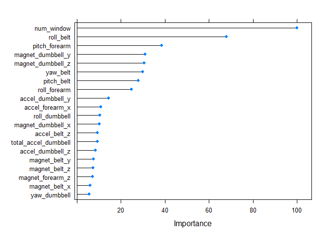

```r
par(mfrow=c(1,2))
rfImp <- varImp(modelrf)
gbImp <- varImp(modelgbm)
plot(rfImp, top = 20)
```

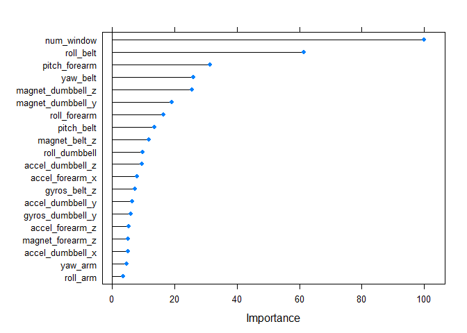

```r
plot(gbImp, top = 20)
```

We can see that both models are fairly similar for thew most important features, which explains the similar performance on our accuracy measure.

## Prediction on the Testing Set

The final prediction for our random forest model is shown next.

```r
predict(modelrf,testing)
```

```
##  [1] B A B A A E D B A A B C B A E E A B B B
## Levels: A B C D E
```